# Applied Machine Learning for Senior Leaders

## Today…

1. Solve a prediction challenge
2. Explore and understand our data with Python
3. Think about how our data is connected, and test our theories
4. Use our findings to build our first model, and see how it performs
5. Use our model to make predictions

## Our Data, and our Challenge

- We’ve built a synthetic dataset of benefit claimants
- Each row is a claimant over the past 12 months
- Divided into:
  - a training dataset (270 individuals)
  - a test dataset (30 indivuals)
- Can we predict the behaviour of claimants in our test dataset?

## Relationships in our data - Correlation

- To make a model, we need to understand how one variable in our data is affected by the others
- A good place to start is with **correlation**
- Correlation is a statisitcla measure of *how much two things are related to each other*, whether they increase or decrease together, or if there is no relationship at all.

## Examples of Correlation

- How well is a person’s age in years correlated with…
- their age in months
- their income
- the length of their name

## Let’s code it!

```python
df[['age','years_in_labour_force']].corr()
```

|  | age | Years in labour force |
| --- | --- | --- |
| age | 1.0 | 0.749 |

- How would you interpret these coefficients?
- Can you find features linked to fraud?

## Building our first regression

```python
mod = smf.ols(formula='years_in_labour_force ~ age', data=df)
res = mod.fit()
res.summary()
```

[output not shown]

- For now, we’ll focus on our **R-squared value**

## Understanding R-Squared

- R-squared is a measure that tells us how well our data fits our model
- I like thinking of it as *how well our model fits*, in percentage terms
- So a model with a R-squared of 1 fits 100% of our data
- …or like *super correlation!*

## Regression Example - Restaurant Bills

```python
mod = smf.ols(formula='tips ~ bill', data=all_bills)
```

[interactive chart not shown]

```python
mod = smf.ols(formula='tips ~ bill + gender', data=all_bills)
```

[interactive chart not shown]

- How does it change when we add features?

## Making our predictions

- Now we have our model, how do we make predictions?
- We just pass it our test data!

```python
mod = smf.ols(formula='committed ~ age + years_in_labour_force + years_of_further_education+', data=train)
res = mod.fit()
predictions = res.predict(test)
```

| person_id | committed | prediction |
| --- | --- | --- |
| 203 | 1 | 0.84 |
| 266 | 1 | 0.58 |

- To help make a binary, *yes or no* prediction, let’s decide anybody over 0.5 is included… then see how we did!

| person_id | age | committed | prediction |
| --- | --- | --- | --- |
| 42 | 29.50843 | 1 | True |
| 281 | 50.42585 | 1 | True |
| 295 | 29.02093 | 0 | True |
| 157 | 34.13484 | 1 | True |
| 238 | 33.00470 | 1 | True |

## From here… to AI!

- We’ve understood how our data connects, and combined it into a model
- The same core methods and principles apply to both what you’ve done today, and cutting edge AI

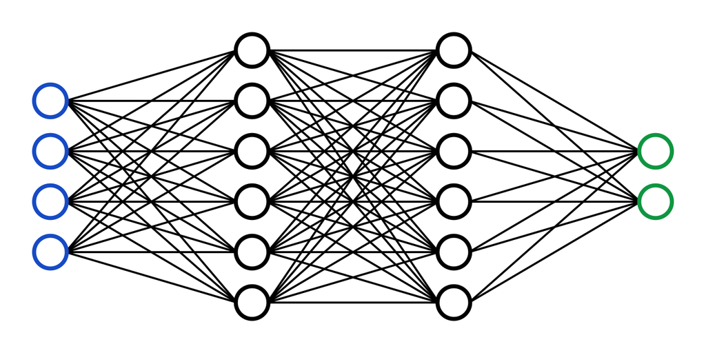

## Thank you!

avarotsis@no10.gov.uk

[figure not shown]

[figure not shown]